# R Notebook

#in library(splitstackshape)

Run the code below before you begin:

```r
library(rpart)
library(rpart.plot)
library(tidyverse)

library(tidyverse)
titanic_set <- read_csv('data/titanic_decision_tree_data.csv')
titanic_set
```

| X1 | passenger_id | pclass | name | sex | age | sib_sp | parch | ticket | fare | cabin | embarked | survived |
| --- | --- | --- | --- | --- | --- | --- | --- | --- | --- | --- | --- | --- |
| 1 | 892 | 3 | Kelly, Mr. James | male | 34.50 | 0 | 0 | 330911 | 7.8292 | NA | Q | NA |
| 2 | 893 | 3 | Wilkes, Mrs. James (Ellen Needs) | female | 47.00 | 1 | 0 | 363272 | 7.0000 | NA | S | NA |
| 3 | 894 | 2 | Myles, Mr. Thomas Francis | male | 62.00 | 0 | 0 | 240276 | 9.6875 | NA | Q | NA |
| 4 | 895 | 3 | Wirz, Mr. Albert | male | 27.00 | 0 | 0 | 315154 | 8.6625 | NA | S | NA |
| 5 | 896 | 3 | Hirvonen, Mrs. Alexander (Helga E Lindqvist) | female | 22.00 | 1 | 1 | 3101298 | 12.2875 | NA | S | NA |
| 6 | 897 | 3 | Svensson, Mr. Johan Cervin | male | 14.00 | 0 | 0 | 7538 | 9.2250 | NA | S | NA |
| 7 | 898 | 3 | Connolly, Miss. Kate | female | 30.00 | 0 | 0 | 330972 | 7.6292 | NA | Q | NA |
| 8 | 899 | 2 | Caldwell, Mr. Albert Francis | male | 26.00 | 1 | 1 | 248738 | 29.0000 | NA | S | NA |
| 9 | 900 | 3 | Abrahim, Mrs. Joseph (Sophie Halaut Easu) | female | 18.00 | 0 | 0 | 2657 | 7.2292 | NA | C | NA |
| 10 | 901 | 3 | Davies, Mr. John Samuel | male | 21.00 | 2 | 0 | A/4 48871 | 24.1500 | NA | S | NA |

[output cut: 990 more lines]

```r
glimpse(titanic_set)
```

```
Rows: 1,309
Columns: 13
$ X1           <dbl> 1, 2, 3, 4, 5, 6, 7, 8, 9, 10, 11, 12, 13, 14, 15, 16, 1…
$ passenger_id <dbl> 892, 893, 894, 895, 896, 897, 898, 899, 900, 901, 902, 9…
$ pclass       <dbl> 3, 3, 2, 3, 3, 3, 3, 2, 3, 3, 3, 1, 1, 2, 1, 2, 2, 3, 3,…
$ name         <chr> "Kelly, Mr. James", "Wilkes, Mrs. James (Ellen Needs)", …
$ sex          <chr> "male", "female", "male", "male", "female", "male", "fem…
$ age          <dbl> 34.5, 47.0, 62.0, 27.0, 22.0, 14.0, 30.0, 26.0, 18.0, 21…
$ sib_sp       <dbl> 0, 1, 0, 0, 1, 0, 0, 1, 0, 2, 0, 0, 1, 1, 1, 1, 0, 0, 1,…
$ parch        <dbl> 0, 0, 0, 0, 1, 0, 0, 1, 0, 0, 0, 0, 0, 0, 0, 0, 0, 0, 0,…
$ ticket       <chr> "330911", "363272", "240276", "315154", "3101298", "7538…
$ fare         <dbl> 7.8292, 7.0000, 9.6875, 8.6625, 12.2875, 9.2250, 7.6292,…
$ cabin        <chr> NA, NA, NA, NA, NA, NA, NA, NA, NA, NA, NA, NA, "B45", N…
$ embarked     <chr> "Q", "S", "Q", "S", "S", "S", "Q", "S", "C", "S", "S", "…
$ survived     <dbl> NA, NA, NA, NA, NA, NA, NA, NA, NA, NA, NA, NA, NA, NA, …
```

```r
summary(titanic_set)
```

```
       X1        passenger_id      pclass          name
 Min.   :   1   Min.   :   1   Min.   :1.000   Length:1309
 1st Qu.: 328   1st Qu.: 328   1st Qu.:2.000   Class :character
 Median : 655   Median : 655   Median :3.000   Mode  :character
 Mean   : 655   Mean   : 655   Mean   :2.295
 3rd Qu.: 982   3rd Qu.: 982   3rd Qu.:3.000
 Max.   :1309   Max.   :1309   Max.   :3.000

     sex                 age            sib_sp           parch
 Length:1309        Min.   : 0.17   Min.   :0.0000   Min.   :0.000
 Class :character   1st Qu.:21.00   1st Qu.:0.0000   1st Qu.:0.000
 Mode  :character   Median :28.00   Median :0.0000   Median :0.000
                    Mean   :29.88   Mean   :0.4989   Mean   :0.385
                    3rd Qu.:39.00   3rd Qu.:1.0000   3rd Qu.:0.000
                    Max.   :80.00   Max.   :8.0000   Max.   :9.000
                    NA's   :263
    ticket               fare            cabin             embarked
 Length:1309        Min.   :  0.000   Length:1309        Length:1309
 Class :character   1st Qu.:  7.896   Class :character   Class :character
 Mode  :character   Median : 14.454   Mode  :character   Mode  :character
                    Mean   : 33.295
                    3rd Qu.: 31.275
                    Max.   :512.329
                    NA's   :1
    survived
 Min.   :0.0000
 1st Qu.:0.0000
 Median :0.0000
 Mean   :0.3838
 3rd Qu.:1.0000
 Max.   :1.0000
 NA's   :418
```

```r
shuffle_index <- sample(1:nrow(titanic_set))

# shuffle the data so class order isn't in order - need this for training/testing split later on
titanic_set <- titanic_set[shuffle_index, ]
```

**Data Dictionary**

- **sex**: Biological Sex, male or female
- **age_status**: adult or child (child defined as under 16)
- **class** : Ticket class, 1 = 1st (Upper class), 2 = 2nd (Middle Class), 3 = 3rd (Lower Class)
- **port_embarkation**: C = Cherbourg, Q = Queenstown, S = Southampton
- **sibsp** : number of siblings / spouses aboard the Titanic
- **parch**: number of parents / children aboard the Titanic. Some children travelled only with a nanny, therefore parch=0 for them.
- **survived_flag** : did they survive, 0 = No, 1 = Yes

# MVP

## Question 1

Cleaning up the data is always the first step. Do the following:

- Take only observations which have a `survived` flag (i.e. that aren’t missing)
- Turn your important variables into factors (sex, survived, pclass, embarkation)
- Create an `age_status` variable which groups individuals under (and including) 16 years of age into a category called “child” category and those over 16 into a category called “adult”.
- Drop the NA
- Drop any variables you don’t need (`X1`, `passenger_id`, `name`, `ticket`, `far`, `cabin`)

```r
titanic_clean <- titanic_set %>%
  filter(survived == 0 | 1) %>%
    mutate(sex = as.factor(sex),
          survived_flag = factor(survived, levels = c(0,1), labels = c("No", "Yes")),
          class = factor(pclass, levels = c(3,2,1), labels = c("Lower", "Middle", "Upper")),
          port_embarked = as.factor(embarked),
          age_status = as.factor(if_else(age <= 16, "child", "adult"))) %>%
          select(-c("X1", "passenger_id", "name", "ticket", "fare", "cabin", "pclass", "embarked", "age", "survived")) %>%
  na.omit()



titanic_clean
```

| sex | sib_sp | parch | survived_flag | class | port_embarked | age_status |
| --- | --- | --- | --- | --- | --- | --- |
| male | 1 | 0 | No | Lower | S | adult |
| female | 1 | 0 | Yes | Upper | C | adult |
| female | 0 | 0 | Yes | Lower | S | adult |
| female | 1 | 0 | Yes | Upper | S | adult |
| male | 0 | 0 | No | Lower | S | adult |
| male | 0 | 0 | No | Upper | S | adult |
| male | 3 | 1 | No | Lower | S | child |
| female | 0 | 2 | Yes | Lower | S | adult |
| female | 1 | 0 | Yes | Middle | C | child |
| female | 1 | 1 | Yes | Lower | S | child |

[output cut: 702 more lines]

## Question 2

Have a look at your data and create some plots to ensure you know what you’re working with before you begin. Write a summary of what you have found in your plots. Which variables do you think might be useful to predict whether or not people are going to die? Knowing this before you start is the best way to have a sanity check that your model is doing a good job.

[output not shown]

[output cut: 702 more lines]

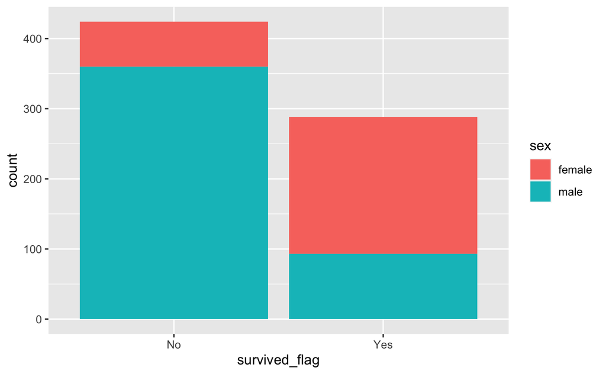

```r
titanic_clean %>%
  ggplot(aes(survived_flag, fill = sex))+
  geom_bar()
```

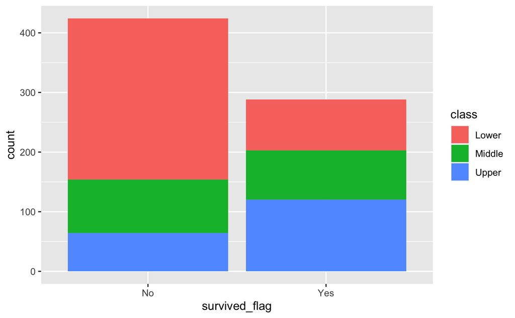

```r
titanic_clean %>%
  ggplot(aes(survived_flag, fill = class))+
  geom_bar()
```

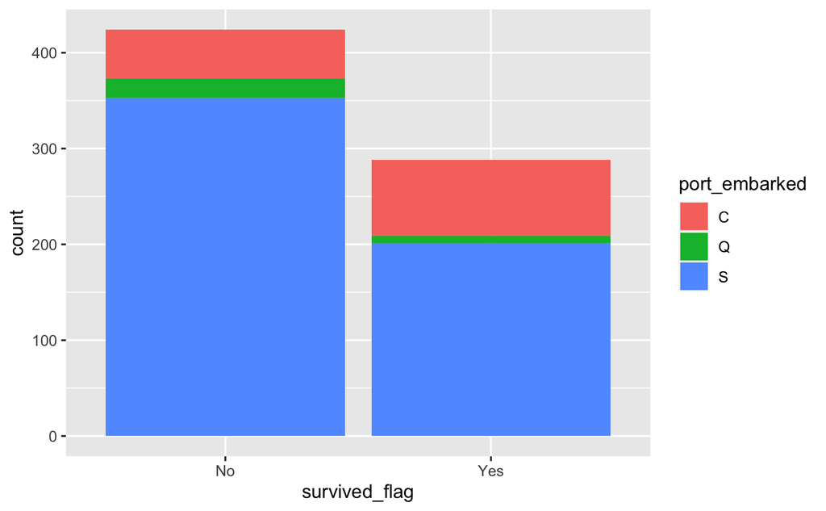

```r
titanic_clean %>%
  ggplot(aes(survived_flag, fill = port_embarked))+
  geom_bar()
```

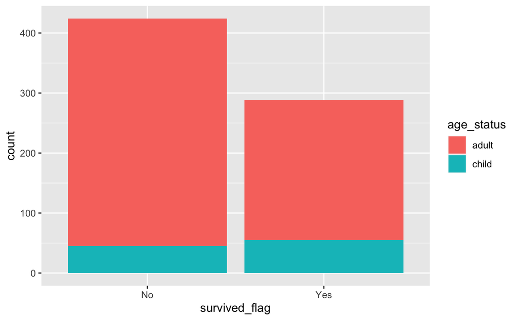

```r
titanic_clean %>%
  ggplot(aes(survived_flag, fill = age_status))+
  geom_bar()
```

## Question 3

Now you can start to build your model. Create your testing and training set using an appropriate split. Check you have balanced sets. Write down why you chose the split you did and produce output tables to show whether or not it is balanced.

```r
# get how many rows we have in total to work out the percentage
n_data <- nrow(titanic_clean)
test_index <- sample(1:n_data, size = n_data*0.2)
```

```r
titanic_clean_test  <- slice(titanic_clean, test_index)
titanic_clean_train <- slice(titanic_clean, -test_index)
```

#testing proportions are evenly split. test-142, train -570

```r
library(janitor)
```

```r
titanic_clean_test %>%
 janitor::tabyl(survived_flag)
```

```
 survived_flag  n   percent
            No 87 0.6126761
           Yes 55 0.3873239
```

```r
titanic_clean_train %>%
 janitor::tabyl(survived_flag)
```

```
 survived_flag   n   percent
            No 337 0.5912281
           Yes 233 0.4087719
```

## Question 4

Create your decision tree to try and predict survival probability using an appropriate method, and create a decision tree plot.

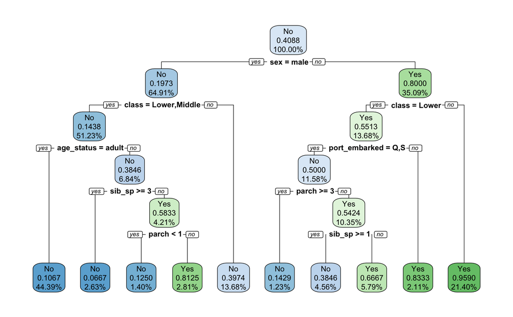

```r
titanic_fit <- rpart(
  formula = survived_flag ~ .,
  data = titanic_clean_train,
  method = 'class'
)

rpart.plot(titanic_fit, yesno = 2, fallen.leaves = TRUE, faclen = 6, digits = 4)
```

## Question 5

Write down what this tells you, in detail. What variables are important? What does each node tell you? Who has the highest chance of surviving? Who has the lowest? Provide as much detail as you can.

## Question 6

Test and add your predicitons to your data. Create a confusion matrix. Write down in detial what this tells you for this specific dataset.

```r
library(modelr)
```

```r
titanic_test_pred <- titanic_clean_test %>%
  add_predictions(titanic_fit, type = 'class')
```

```r
# look at the variables
titanic_test_pred %>%
  select(sex, class, age_status, survived_flag, pred)
```

| sex | class | age_status | survived_flag | pred |
| --- | --- | --- | --- | --- |
| female | Lower | adult | No | No |
| female | Upper | adult | Yes | Yes |
| male | Middle | adult | No | No |
| male | Lower | adult | No | No |
| female | Middle | child | Yes | Yes |
| female | Upper | adult | Yes | Yes |
| male | Lower | adult | No | No |
| male | Middle | adult | No | No |
| male | Lower | adult | No | No |
| female | Upper | adult | Yes | Yes |

[output cut: 132 more lines]

```r
library(caret)
```

Accuracy of predicting whether someone survived on titanic is 0.78 with true negatives 72 versus false negatives of 17 and false positives 15 versus true positves of 38.

```r
confusionMatrix(titanic_test_pred$pred, titanic_test_pred$survived_flag) #order is estimate and then truth
```

```
Confusion Matrix and Statistics

          Reference
Prediction No Yes
       No  72  17
       Yes 15  38

               Accuracy : 0.7746
                 95% CI : (0.697, 0.8405)
    No Information Rate : 0.6127
    P-Value [Acc > NIR] : 2.999e-05

                  Kappa : 0.522

 Mcnemar's Test P-Value : 0.8597

            Sensitivity : 0.8276
            Specificity : 0.6909
         Pos Pred Value : 0.8090
         Neg Pred Value : 0.7170
             Prevalence : 0.6127
         Detection Rate : 0.5070
   Detection Prevalence : 0.6268
      Balanced Accuracy : 0.7592

       'Positive' Class : No
```